# HW_Credit_Card_Fraud

Elijah Hall

June 11, 2018

## Case 3: Credit Card Fraud

Credit card fraud happens basically in two types: 1) Application fraud: similar to identity fraud that one person uses another person’s personal data to obtain a new card. 2) Transaction fraud: When a card is stolen or a lost card is obtained to conduct fraudulent transactions. A fraudster will try to abuse the card as much as possible in a short period of time before the card is detected and suspended. So we should see **abnormal transactions** in a **short period of time**. (Infromation taken from course presentation, an introduction to Credit Card Fraud)

### Oklahoma purchase credit card transactions

The Office of Management and Enterprise Services in the State of Oklahoma has made its [purchase credit card transactions](https://catalog.data.gov/dataset/purchase-card-pcard-fiscal-year-2014) available. This dataset contains information on purchases made through the purchase card programs administered by the state and higher education institutions.

- Each feature or discussion is a new lead. Structure your EDA for different leads with sub-sections. Each sub-section will cover the following:
  - Lead: Write what you are going to do in two to three sentences.
  - Analysis: your EDA
  - Conclusion: What is the business insight? How can this feature help prediction? Write a short conclusion in the end of each sub-section.
- Submit in the HTML format.

```r
library(rmarkdown)
library(tidyverse)
library(lubridate)
library(data.table)

library(TTR)
library(zoo)
library(cumstats)
library(corrplot)
```

### Exploratory Data Analysis

```r
dim(ccdf)
```

```
## [1] 442458     11
```

```r
summary(ccdf)
```

```
##    Year-Month     Agency Number   Agency Name        Cardholder Last Name
##  Min.   :201307   Min.   : 1000   Length:442458      Length:442458
##  1st Qu.:201309   1st Qu.: 1000   Class :character   Class :character
##  Median :201401   Median :47700   Mode  :character   Mode  :character
##  Mean   :201357   Mean   :42786
##  3rd Qu.:201404   3rd Qu.:76000
##  Max.   :201406   Max.   :98000
##  Cardholder First Initial Description            Amount
##  Length:442458            Length:442458      Min.   : -42863.0
##  Class :character         Class :character   1st Qu.:     30.9
##  Mode  :character         Mode  :character   Median :    104.9
##                                              Mean   :    425.0
##                                              3rd Qu.:    345.0
##                                              Max.   :1903858.4
##     Vendor          Transaction Date   Posted Date
##  Length:442458      Length:442458      Length:442458
##  Class :character   Class :character   Class :character
##  Mode  :character   Mode  :character   Mode  :character
##
##
##
##  Merchant Category Code (MCC)
##  Length:442458
##  Class :character
##  Mode  :character
##
##
##
```

```r
colnames(ccdf)
```

```
##  [1] "Year-Month"                   "Agency Number"
##  [3] "Agency Name"                  "Cardholder Last Name"
##  [5] "Cardholder First Initial"     "Description"
##  [7] "Amount"                       "Vendor"
##  [9] "Transaction Date"             "Posted Date"
## [11] "Merchant Category Code (MCC)"
```

So the data set is 442,458 rows by 11 columns. The different variable types will need to explored and set to make for easier analysis. First I want to rename the variables to make for easier use. Then I will explore each variable.

```r
#rename columns
colnames(ccdf)<-c('Year_Month', 'Agency_Number', 'Agency_Name', 'Cardholder_Last_Name',
      'Cardholder_First_Initial', 'Description', 'Amount', 'Vendor', 'Transaction_Date',
      'Posted_Date', 'Merchant_Category')

# Count of agencies
length(unique(ccdf$Agency_Name))
```

```
## [1] 124
```

```r
# 124

# Count of Vendor
length(unique(ccdf$Vendor))
```

```
## [1] 86729
```

```r
# 86,729

# Count of Merchant_Category
length(unique(ccdf$Merchant_Category))
```

```
## [1] 435
```

```r
# 435
```

```r
#convert dategorical variables to factors
ccdf$Agency_Name<- factor(ccdf$Agency_Name)
ccdf$Vendor <- factor(ccdf$Vendor)
ccdf$Merchant_Category <- factor(ccdf$Merchant_Category)
ccdf$Description<- factor(ccdf$Description)

#combine Last name and First initial and reduce variabels by removing last name and first initial variables
ccdf <- ccdf%>%
  mutate(Last.FI = paste0(Cardholder_Last_Name,".",Cardholder_First_Initial))
ccdf <- ccdf[, c(1,2,3,12,6,7,8,9,10,11)]

#convert times to DTG type, note that the H:M:S are all "12:00:00 AM"
ccdf$Transaction_Date <- mdy_hms(ccdf$Transaction_Date)
ccdf$Posted_Date <- mdy_hms(ccdf$Posted_Date)
head(ccdf$Transaction_Date,10)
```

```
##  [1] "2013-07-30 UTC" "2013-07-30 UTC" "2013-07-29 UTC" "2013-07-30 UTC"
##  [5] "2013-07-30 UTC" "2013-07-29 UTC" "2013-07-30 UTC" "2013-07-29 UTC"
##  [9] "2013-07-30 UTC" "2013-07-30 UTC"
```

```r
head(ccdf$Posted_Date,10)
```

```
##  [1] "2013-07-31 UTC" "2013-07-31 UTC" "2013-07-31 UTC" "2013-07-31 UTC"
##  [5] "2013-07-31 UTC" "2013-07-31 UTC" "2013-07-31 UTC" "2013-07-31 UTC"
##  [9] "2013-07-31 UTC" "2013-07-31 UTC"
```

```r
#create a summarized df
stat_by_agency <- ccdf %>% group_by(Agency_Name) %>%
    summarise(count = n(),
              amount = sum(Amount),
              mean = mean(Amount),
              min = min(Amount),
              max = max(Amount)
             ) %>%
    arrange(desc(amount)) %>% ungroup()

#create additional variables
stat_by_agency <- stat_by_agency %>%
    mutate(row = rep(1:nrow(stat_by_agency)),
          Agency_Name_ind = paste(row,Agency_Name,sep="_"),
          percent = amount/sum(amount)) %>%
    select(Agency_Name_ind,count, amount, percent,mean, min, max)

head(stat_by_agency)
```

```
## # A tibble: 6 x 7
##   Agency_Name_ind              count   amount percent  mean     min    max
##   <chr>                        <int>    <dbl>   <dbl> <dbl>   <dbl>  <dbl>
## 1 1_OKLAHOMA STATE UNIVERSITY 115995   3.38e7  0.180   291.  -6267. 2.80e4
## 2 2_UNIVERSITY OF OKLAHOMA     76143   2.49e7  0.132   327. -41740  1.14e5
## 3 3_UNIV. OF OKLA. HEALTH SC~  58247   2.45e7  0.130   421.  -7189. 1.90e6
## 4 4_GRAND RIVER DAM AUTH.      10427   2.22e7  0.118  2130.  -9000  1.09e6
## 5 5_DEPARTMENT OF TRANSPORTA~  15689   1.44e7  0.0766  918. -34108  3.48e5
## 6 6_DEPARTMENT OF CORRECTIONS  22322   1.40e7  0.0744  627. -20000  9.62e4
```

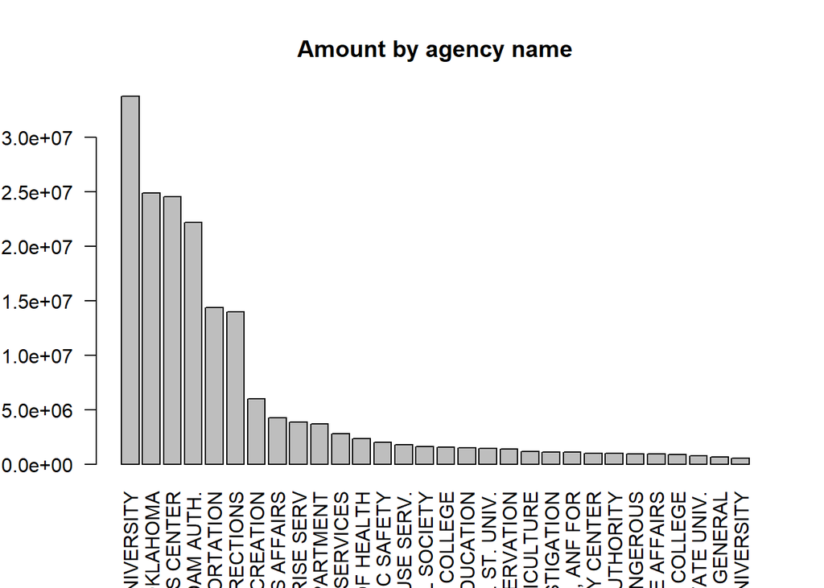

```r
# Simple Bar Plots
temp <-stat_by_agency[1:30,]
barplot(temp$amount,names.arg=temp$Agency_Name_ind,
main="Amount by agency name",las=2       )
```

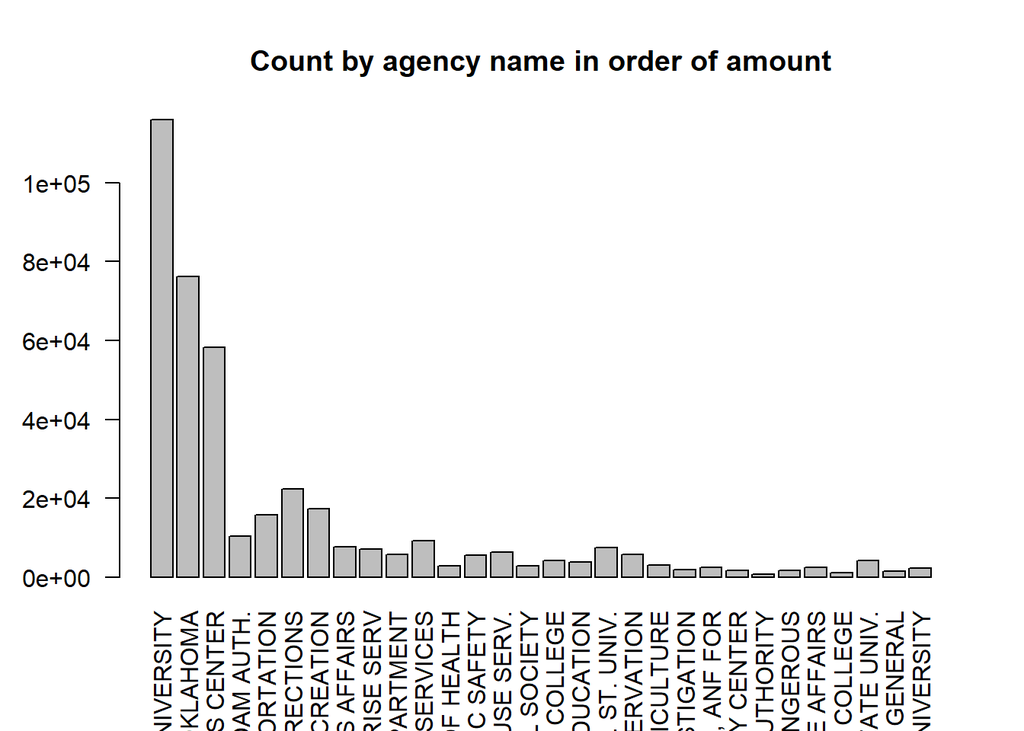

```r
barplot(temp$count,names.arg=temp$Agency_Name_ind,
main="Count by agency name in order of amount",las=2       )
```

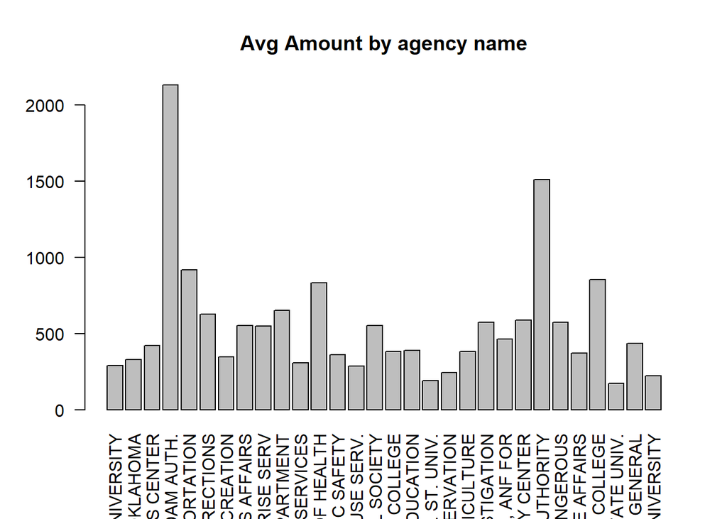

```r
barplot(temp$mean,names.arg=temp$Agency_Name_ind,
main="Avg Amount by agency name",las=2       )
```

```r
stat_by_merchant_category <- ccdf %>% group_by(Merchant_Category) %>%
    summarise(count = n(),
              amount = sum(Amount),
              mean = mean(Amount),
              min = min(Amount),
              max = max(Amount)
             ) %>%
    arrange(desc(amount)) %>%
  ungroup()

#create additional variables
stat_by_merchant_category <- stat_by_merchant_category %>%
    mutate(row = rep(1:nrow(stat_by_merchant_category)),
          Merchant_Category_ind = paste(row,Merchant_Category,sep="_"),
          percent = amount/sum(amount)) %>%
    select(Merchant_Category_ind,count, amount, percent,mean, min, max)

head(stat_by_merchant_category)
```

```
## # A tibble: 6 x 7
##   Merchant_Category_ind         count  amount percent  mean     min    max
##   <chr>                         <int>   <dbl>   <dbl> <dbl>   <dbl>  <dbl>
## 1 1_DENTAL/LABORATORY/MEDICAL/~ 20183  1.10e7  0.0585  545. -41740  7.42e4
## 2 2_INDUSTRIAL SUPPLIES NOT EL~ 21669  1.08e7  0.0577  501. -10140  9.62e4
## 3 3_COMPUTERS, COMPUTER PERIPH~  5504  1.01e7  0.0537 1834.  -4021. 8.15e5
## 4 4_COMMERCIAL EQUIPMENT, NOT ~  6969  8.14e6  0.0433 1168.  -9000  1.09e6
## 5 5_MISCELLANEOUS AND SPECIALT~ 13335  5.56e6  0.0296  417.  -4455. 8.02e4
## 6 6_AMERICAN AIRLINES           12015  5.30e6  0.0282  441.  -3350  7.77e3
```

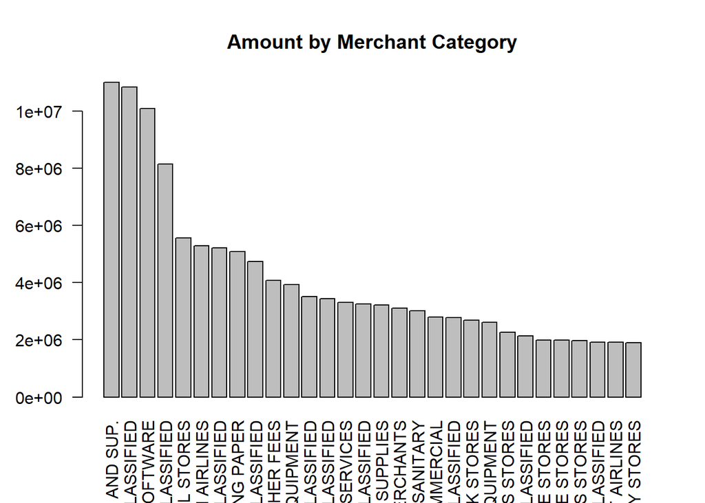

```r
# Simple Bar Plot
temp <-stat_by_merchant_category[1:30,]
barplot(temp$amount,names.arg=temp$Merchant_Category_ind,
main="Amount by Merchant Category",las=2       )
```

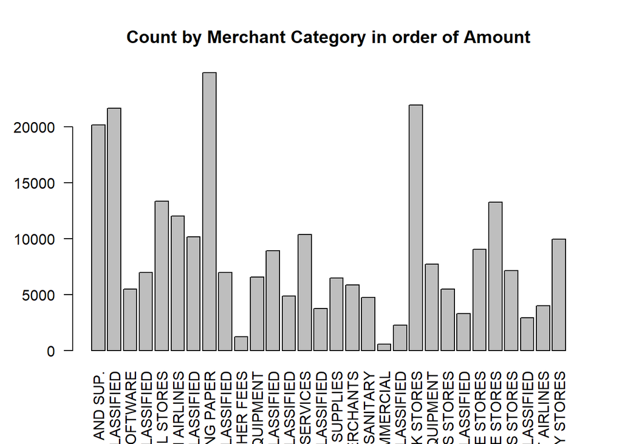

```r
barplot(temp$count,names.arg=temp$Merchant_Category_ind,
main="Count by Merchant Category in order of Amount",las=2       )
```

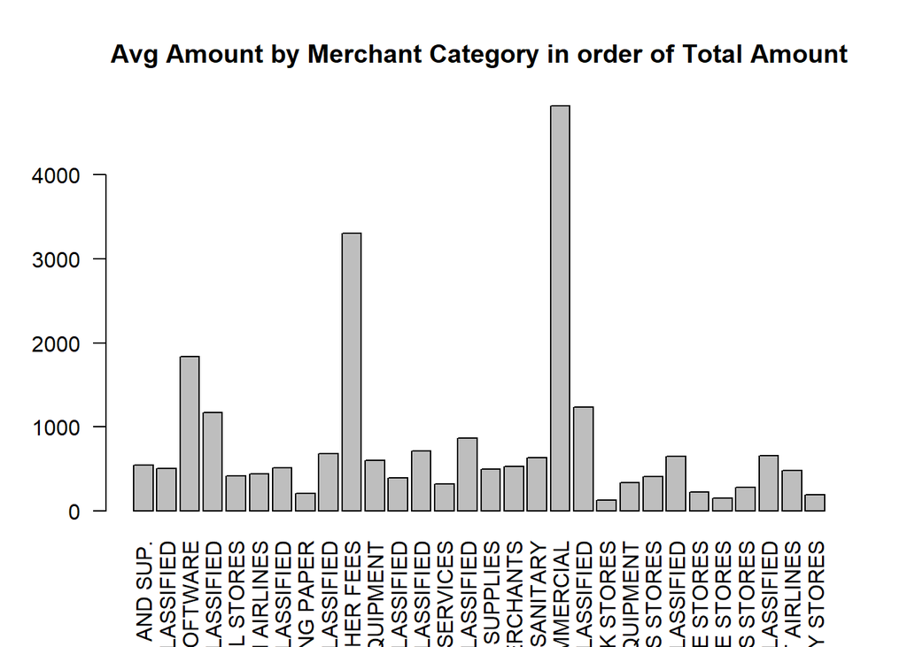

```r
barplot(temp$mean,names.arg=temp$Merchant_Category_ind,
main="Avg Amount by Merchant Category in order of Total Amount",las=2       )
```

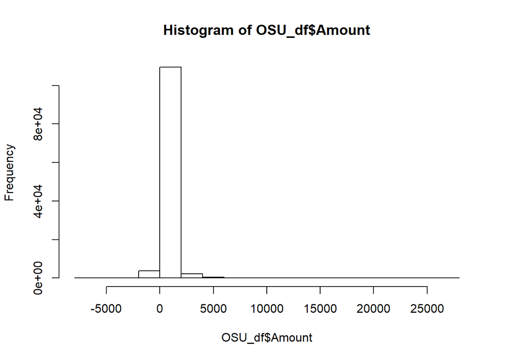

```r
# EDA for OKLAHOMA STATE UNIVERSITY transactions
OSU_df<- ccdf%>%
  group_by(Agency_Name)%>%
  filter(Agency_Name=="OKLAHOMA STATE UNIVERSITY")

hist(OSU_df$Amount)
```

```r
summary(OSU_df$Amount)
```

```
##     Min.  1st Qu.   Median     Mean  3rd Qu.     Max.
## -6266.53    33.29   100.00   291.21   299.48 27967.38
```

```r
length(OSU_df$Merchant_Category[which(OSU_df$Amount < -1000)])
```

```
## [1] 121
```

### Featrue engineering

For these features I will focus on the Recency, Frequency, Monetary (RFM) structured analysis.

To assign customer events to RFM cells, the three RFM variables are turned into quantiles.

*Recency* - the number of days or weeks since the last purchase - is used to assign the R score, typically by dividing the values into three groups (terciles) or fi ve groups (quintiles). This is important and can be used for various time windows. Early identification will want to explore the smallest windows to be able to identify and stop as early as possible fraudulent activity.

The second variable, *Frequency*, is usually defined as the total number of previous purchases. Customers are given F scores based on their frequency quantile. Many faudsters test the card at specific places such as a gas station or convenient store before starting a spree of purchases.

The last variable, *Monetary*, is total lifetime spending, which is used to create M scores. This can be broken down into many categories depending onthe context. But knowing the average spending habits of a customer and range of spending at types of stores is important to detect anomalies.

Reference: Linoff, Gordon, and Michael J. A. Berry. Data Mining Techniques: For Marketing ; Sales ; and Customer Relationship Management . 3rd ed., John Wiley & Sons Incorporated, 2011.

“avg maximum adjusted by time, day, week, etc…” “create maximum or avg per merchants by time, day, week, etc…” “avg spending by industry or SIC code if you can identify the industry”

### Feature engineering: Recency

#### Helper function

I attempted to make the function to adjust for different times but couldn’t find a way to subset by mutiple categorical variables and wouldn’t eat up massive amount of processing time.

```r
"create function to adjust time variables such as rolling average by day, week, 2 week, month, etc"
moving_avg<- function (x, frequency = c("day","week","2week", "month", "3month"), time.var.name) {
  if(frequency == "day"){
    t = 1
    means
  } else if(frequency == "week"){
    t = 7
  } else if(frequency == "2week"){
    t = 14
  } else if(frequency == "month"){
     t = 30
  } else if(frequency == "3month"){
    t = 90
  } else{
    stop("Must assign one of the following: day, week, 2week, month, 3month in quotes")
  }


adj_dates <- ymd(x$time.var.name) - dday(t-1)

means<- vector("numeric", length = nrow(x))

for(i in 1:nrow(x)) {
  x_sub<-x$amount.name[ymd(x$time.var.name) - dday(t-1):ymd(x$time.var.name)]
  means[i]
}


return(means)

}

#Testing strategies
ccdf<-ccdf%>%
  group_by(Agency_Name, Transaction_Date)%>%
  arrange(Agency_Name, Transaction_Date)%>%
  mutate(daymean = mean(Amount))

all_dates<- unique(ccdf$Transaction_Date)
all_agency<- unique(ccdf$Agency_Name)
means<- c()
for(i in 1:length(all_dates)){
  idx <- which(ymd(ccdf$Transaction_Date)==ymd(all_dates[i]))
  for( j in 1:length(all_agency)){
    sub_df<-ccdf[idx,]
    idj<-which(sub_df$Agency_Name == all_agency[j])
    means<- c(means, mean(sub_df$Amount[idj], na.rm = T))
  }
}
#not working

test<-ccdf[which(ymd(ccdf$Transaction_Date) == ymd(all_dates[1])),]
test<-test[which(test$Agency_Name == all_agency[1]),]

day_means<- vector("numeric", length= nrow(ccdf))
for(i in 1:length(idx)){
  day_means[unlist(idx[i])]<-means[i]
}

ccdf$day_means<-day_means
```

#### Feature 1: Create timestamp

The first feature is the one demonstated in class. This is to create a timestamp and time between transactions. This is important as mentioned above to identify those points were transactions are purchased with little time between. This goes to understanding normal beahvior of the client and identifying those that are not normal.

```r
time_by_agency <- ccdf %>%
    group_by(Agency_Name) %>%
    arrange(Agency_Name,Transaction_Date) %>%
    mutate(time = ymd(Transaction_Date)-lag(ymd(Transaction_Date)) )

time_by_agency[,c("Agency_Number","Agency_Name", "Transaction_Date", "time")]
```

```
## # A tibble: 442,458 x 4
## # Groups:   Agency_Name [124]
##    Agency_Number Agency_Name              Transaction_Date    time
##            <int> <fct>                    <dttm>              <time>
##  1         26500 `DEPARTMENT OF EDUCATION 2013-06-29 00:00:00 <NA>
##  2         26500 `DEPARTMENT OF EDUCATION 2013-07-01 00:00:00 2
##  3         26500 `DEPARTMENT OF EDUCATION 2013-07-01 00:00:00 0
##  4         26500 `DEPARTMENT OF EDUCATION 2013-07-03 00:00:00 2
##  5         26500 `DEPARTMENT OF EDUCATION 2013-07-03 00:00:00 0
##  6         26500 `DEPARTMENT OF EDUCATION 2013-07-03 00:00:00 0
##  7         26500 `DEPARTMENT OF EDUCATION 2013-07-03 00:00:00 0
##  8         26500 `DEPARTMENT OF EDUCATION 2013-07-03 00:00:00 0
##  9         26500 `DEPARTMENT OF EDUCATION 2013-07-03 00:00:00 0
## 10         26500 `DEPARTMENT OF EDUCATION 2013-07-03 00:00:00 0
## # ... with 442,448 more rows
```

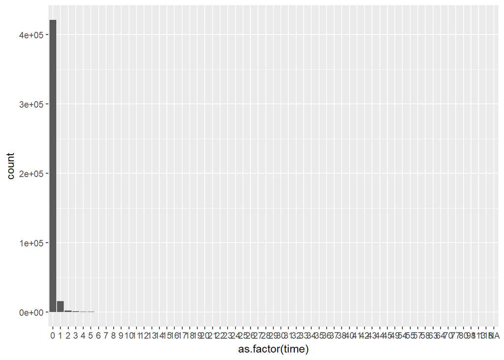

```r
ggplot(time_by_agency, aes(x=as.factor(time)))+geom_histogram(stat= "count")
```

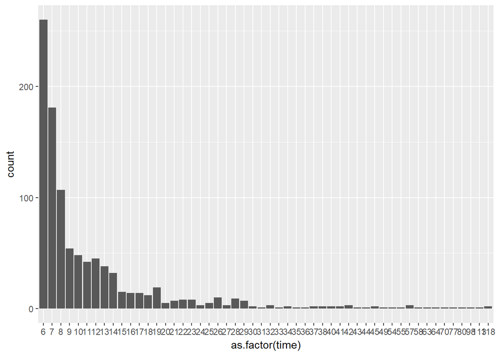

```r
#look at the right tail
ggplot(time_by_agency[which(time_by_agency$time>5),], aes(x=as.factor(time)))+geom_histogram(stat= "count")
```

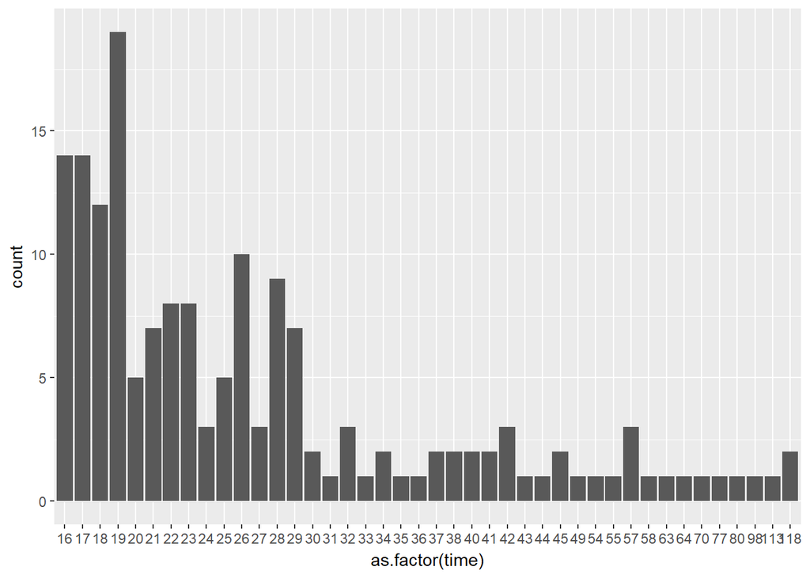

```r
ggplot(time_by_agency[which(time_by_agency$time>15),], aes(x=as.factor(time)))+geom_histogram(stat= "count")
```

Looking at this most transactions are made with less than a 2 days between transactions. However this is not surprising. Also we expect that fraudsters will want to make as many transactions as possible before they are caught. So the likelihood of a fraudster making a transaction more than 2 days apart is low.

### Feature engineering: Frequency

As mentioned Frequency is a very important measurment to observe when trying to catch credit fraud. We want explore these kinds of features a bit more and create some intuitive measurements.

Let’s use one Agency, DEPARTMENT OF EDUCATION, to look at.

```r
doe_df<-time_by_agency %>%
  filter(Agency_Number ==26500) %>%
  group_by(Vendor,Merchant_Category)
```

#### Total number of transactions with same merchant during past 30 days

People tend to visit certain types of places with different frequencies. You will go to a grocery store more often than an auto mechanic. This behavior will be relatively constant and any deviations from these patterns should be identified.

```r
ccdf3<- ccdf%>%
  group_by(Merchant_Category, Transaction_Date)%>%
  summarise(count=n())

last_30<- c()
for(i in 1:nrow(ccdf3)){
  i-1
  sub <- ccdf3[which(ccdf3$Merchant_Category == ccdf3$Merchant_Category[i]),]
  dates<- seq.Date(ymd(sub$Transaction_Date[i])-ddays(30), ymd(sub$Transaction_Date[i]), by = "days")

  last_30[i]<- sub[which(ymd(dates) %in% ymd(sub$Transaction_Date)),]
}




which(ymd(doe_df_counts$Transaction_Date)<= ymd(doe_df_counts$Transaction_Date[10]) & ymd(doe_df_counts$Transaction_Date) > ymd(doe_df_counts$Transaction_Date[10]) - ddays(30) )


all_dates<- unique(doe_df_counts$Transaction_Date)
last30<- vector()
for(i in 1:length(all_dates)){
  idx <- which(ymd(doe_df_counts$Transaction_Date)==ymd(all_dates[i]))
  sub_df<-doe_df_counts[idx,]
  last30[i]<- c(means, mean(sub_df$Amount[idj], na.rm = T))
}
```

I couldn’t find a reasonable way to measure the difference in time for the past 30 days.

### Feature engineering: Monetary

Create features that identify the amounts that our outside the normal distributions. One factor in identifying unusual activity is if the amount being charged is not likely to be observed

#### Average amount spent per transaction over a month on all transactions

```r
ccdfm<- ccdf%>%
  group_by(Last.FI, Merchant_Category, Year_Month)%>%
  summarise(count= n(),
            avg= round(mean(Amount)),
            min= min(Amount),
            max= max(Amount))%>%
  ungroup()

head(ccdfm,15)
```

```
## # A tibble: 15 x 7
##    Last.FI Merchant_Category Year_Month count   avg      min     max
##    <chr>   <fct>                  <int> <int> <dbl>    <dbl>   <dbl>
##  1 15000.1 OTHER FEES            201404     1  4626  4626.   4626.
##  2 24100.2 OTHER FEES            201307     2   906    16.9  1796.
##  3 24100.2 OTHER FEES            201308     2   375    14.5   734.
##  4 24100.2 OTHER FEES            201309     1     7     6.54    6.54
##  5 24100.2 OTHER FEES            201312     2   125     0.04  250
##  6 24100.2 OTHER FEES            201401     1     1     0.77    0.77
##  7 24100.2 OTHER FEES            201403     2   -18   -35.3     0.01
##  8 42000.4 OTHER FEES            201307     1     1     1.17    1.17
##  9 42000.4 OTHER FEES            201308     2   176     2.13  350.
## 10 42000.4 OTHER FEES            201309     1     2     1.86    1.86
## 11 42000.4 OTHER FEES            201312     1   250   250     250
## 12 42000.4 OTHER FEES            201401     2   125     0.14  250
## 13 42000.4 OTHER FEES            201402     2   149     0.85  296.
## 14 42000.4 OTHER FEES            201403     2   137     1.71  272.
## 15 42000.4 OTHER FEES            201404     2   197     1.87  392.
```

```r
summary(ccdfm)
```

```
##    Last.FI
##  Length:185230
##  Class :character
##  Mode  :character
##
##
##
##
##                                                Merchant_Category
##  GROCERY STORES,AND SUPERMARKETS                        :  7932
##  MISCELLANEOUS AND SPECIALTY RETAIL STORES              :  7715
##  BOOK STORES                                            :  6858
##  STATIONERY, OFFICE SUPPLIES, PRINTING AND WRITING PAPER:  6342
##  INDUSTRIAL SUPPLIES NOT ELSEWHERE CLASSIFIED           :  6011
##  HOME SUPPLY WAREHOUSE STORES                           :  5915
##  (Other)                                                :144457
##    Year_Month         count              avg
##  Min.   :201307   Min.   :  1.000   Min.   : -20000.0
##  1st Qu.:201309   1st Qu.:  1.000   1st Qu.:     50.0
##  Median :201401   Median :  1.000   Median :    138.0
##  Mean   :201357   Mean   :  2.389   Mean   :    478.5
##  3rd Qu.:201404   3rd Qu.:  2.000   3rd Qu.:    385.0
##  Max.   :201406   Max.   :532.000   Max.   :1903858.0
##
##       min                 max
##  Min.   : -42863.0   Min.   : -20000.0
##  1st Qu.:     25.4   1st Qu.:     60.0
##  Median :     83.8   Median :    175.0
##  Mean   :    362.2   Mean   :    662.9
##  3rd Qu.:    271.7   3rd Qu.:    500.0
##  Max.   :1903858.4   Max.   :1903858.4
##
```

This shows that some max value as high as $1.9 million and min value as low as -$42,863. I was not expecting that. It looks like some kind of funding for large projects. lets look at the distributions of these.

```r
# transactions over $1mil
ccdf[which(ccdf$Amount>1000000),]
```

```
##        Year_Month Agency_Number                           Agency_Name
## 212077     201308         77000 UNIV. OF OKLA. HEALTH SCIENCES CENTER
## 218926     201309         77000 UNIV. OF OKLA. HEALTH SCIENCES CENTER
## 251919     201310         98000                 GRAND RIVER DAM AUTH.
##             Last.FI      Description  Amount               Vendor
## 212077      77000.7 GENERAL PURCHASE 1750380   PAYMENT ADJUSTMENT
## 218926      77000.7 GENERAL PURCHASE 1903858   PAYMENT ADJUSTMENT
## 251919 Cardholder.e GENERAL PURCHASE 1089180 PELCO STRUCTURAL LLC
##        Transaction_Date Posted_Date
## 212077       2013-07-19  2013-08-05
## 218926       2013-08-21  2013-09-12
## 251919       2013-10-25  2013-10-28
##                                     Merchant_Category
## 212077                                     OTHER FEES
## 218926                                     OTHER FEES
## 251919 COMMERCIAL EQUIPMENT, NOT ELSEWHERE CLASSIFIED
```

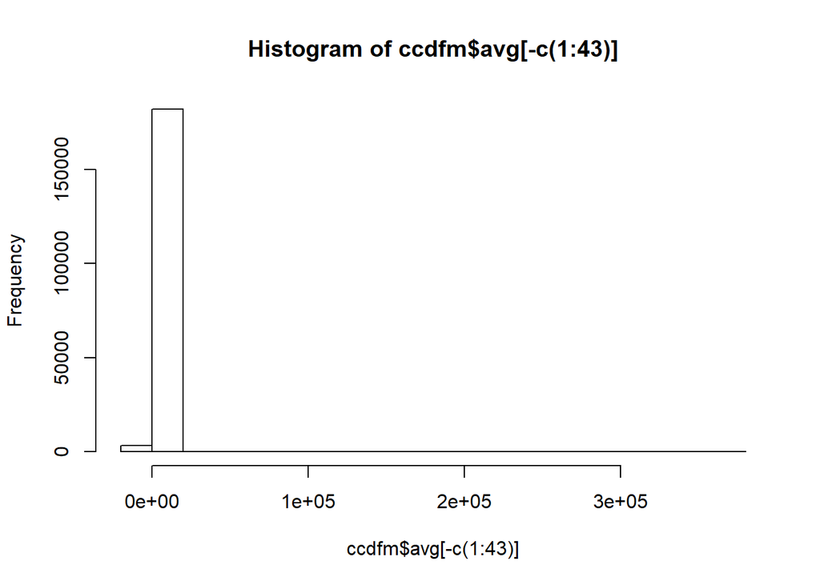

```r
hist(ccdfm$avg[-c(1:43)])
```

As the summary stats showed there are so many observations in the 0-500 range that when the extreme values are included they make it difficult to see the overall distribution.So Lets pick on person.

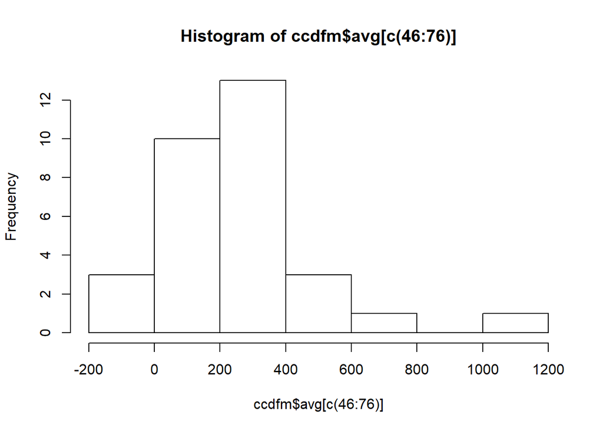

```r
hist(ccdfm$avg[c(46:76)])
```

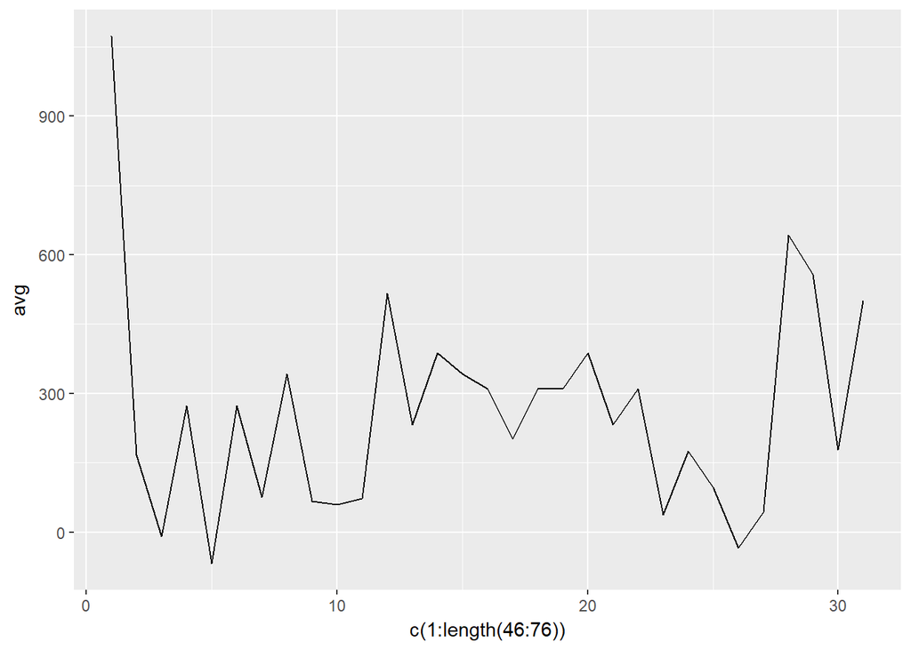

```r
ggplot(ccdfm[c(46:76),], aes(x=c(1:length(46:76)), y=avg)) + geom_line()
```